# IMPORTING THE DELTA VARIANT DATA-SET

- The following data-set consist of tweets from the month of 'June' to the month of 'October'based on the keyword [deltavariant] which has been scrapped from twitter using the library called snscrape
- In this sentiment Analysis we are going to check public sentiments for Covid19 in the secound quater of 2021 which is between june 2021 - october 2021 to check the intensity of Delta Variant in the 2nd quater of 2021.
- Our scrapped data consist of the Url, date of the tweet, tweet_content, tweet_id
- For our Analysis we will be only making use of the tweet content inorder to get the sentiment Analysis for the given time duration

```python
import pandas as pd
df= pd.read_csv('/content/drive/MyDrive/Colab Notebooks/Delta_Variant_second_quater_06-10.csv',low_memory=False)
df
```

|  | Unnamed: 0 | Unnamed: 0.1 | _type | url | date | content | renderedContent | id | user | replyCount | retweetCount | likeCount | quoteCount | conversationId | lang | source | sourceUrl | sourceLabel | outlinks | tcooutlinks | media | retweetedTweet | quotedTweet | inReplyToTweetId | inReplyToUser | mentionedUsers | coordinates | place | hashtags | … |
| --- | --- | --- | --- | --- | --- | --- | --- | --- | --- | --- | --- | --- | --- | --- | --- | --- | --- | --- | --- | --- | --- | --- | --- | --- | --- | --- | --- | --- | --- | --- |
| 0 | 0 | 0 | snscrape.modules.twitter.Tweet | https://twitter.com/gmanews/status/13998746527... | 2021-06-01 23:45:00+00:00 | The World Health Organization (WHO) said Tuesd... | The World Health Organization (WHO) said Tuesd... | 1399874652764246022 | {'_type': 'snscrape.modules.twitter.User', 'us... | 1 | 8 | 7 | 0 | 1399874652764246022 | en | <a href="https://about.twitter.com/products/tw... | https://about.twitter.com/products/tweetdeck | TweetDeck | ['https://www.gmanetwork.com/news/scitech/scie... | ['https://t.co/dBXHAqg5pa'] | NaN | NaN | NaN | NaN | NaN | NaN | NaN | NaN | NaN | … |
| 1 | 1 | 1 | snscrape.modules.twitter.Tweet | https://twitter.com/plaidanimal/status/1399872... | 2021-06-01 23:37:25+00:00 | What We Know About the Dangerous COVID B.1.617... | What We Know About the Dangerous COVID B.1.617... | 1399872745807106048 | {'_type': 'snscrape.modules.twitter.User', 'us... | 0 | 0 | 0 | 0 | 1399872745807106048 | en | <a href="https://mobile.twitter.com" rel="nofo... | https://mobile.twitter.com | Twitter Web App | ['http://a.msn.com/05/en-us/AAKBDq4?ocid=st'] | ['https://t.co/PnEcNRKzQ1'] | NaN | NaN | NaN | NaN | NaN | NaN | NaN | NaN | NaN | … |
| 2 | 2 | 2 | snscrape.modules.twitter.Tweet | https://twitter.com/EagleNews/status/139987167... | 2021-06-01 23:33:11+00:00 | WHO narrows in on Covid Delta variant\n\nRead ... | WHO narrows in on Covid Delta variant\n\nRead ... | 1399871679757697024 | {'_type': 'snscrape.modules.twitter.User', 'us... | 0 | 0 | 3 | 0 | 1399871679757697024 | en | <a href="http://www.eaglenews.ph" rel="nofollo... | http://www.eaglenews.ph | Eagle News AutoPublish | ['https://www.eaglenews.ph/who-narrows-in-on-c... | ['https://t.co/8wJa0ghPFj'] | [{'_type': 'snscrape.modules.twitter.Photo', '... | NaN | NaN | NaN | NaN | NaN | NaN | NaN | ['eaglenews'] | … |
| 3 | 3 | 3 | snscrape.modules.twitter.Tweet | https://twitter.com/petbugs13/status/139987081... | 2021-06-01 23:29:44+00:00 | and then there's the UK, which remains the mos... | and then there's the UK, which remains the mos... | 1399870812794982405 | {'_type': 'snscrape.modules.twitter.User', 'us... | 1 | 0 | 1 | 1 | 1399867416495067136 | en | <a href="https://mobile.twitter.com" rel="nofo... | https://mobile.twitter.com | Twitter Web App | NaN | NaN | [{'_type': 'snscrape.modules.twitter.Photo', '... | NaN | NaN | 1.399870e+18 | {'_type': 'snscrape.modules.twitter.User', 'us... | NaN | NaN | NaN | NaN | … |
| 4 | 4 | 4 | snscrape.modules.twitter.Tweet | https://twitter.com/ScienceAccion/status/13998... | 2021-06-01 23:29:16+00:00 | "No queremos ver el daño social, psicológico y... | "No queremos ver el daño social, psicológico y... | 1399870695509798914 | {'_type': 'snscrape.modules.twitter.User', 'us... | 0 | 0 | 0 | 1 | 1399870695509798914 | es | <a href="https://mobile.twitter.com" rel="nofo... | https://mobile.twitter.com | Twitter Web App | ['https://twitter.com/BBCNewsnight/status/1399... | ['https://t.co/ZI8R956uGT'] | NaN | NaN | {'_type': 'snscrape.modules.twitter.Tweet', 'u... | NaN | NaN | [{'_type': 'snscrape.modules.twitter.User', 'u... | NaN | NaN | ['B16172', 'DeltaVariant'] | … |
| ... | ... | ... | ... | ... | ... | ... | ... | ... | ... | ... | ... | ... | ... | ... | ... | ... | ... | ... | ... | ... | ... | ... | ... | ... | ... | ... | ... | ... | ... | … |
| 75495 | 15495 | 495 | snscrape.modules.twitter.Tweet | https://twitter.com/judinebr/status/1454826838... | 2021-10-31 15:05:22+00:00 | Vaccinated people are just as likely as unvacc... | Vaccinated people are just as likely as unvacc... | 1454826838010699785 | {'_type': 'snscrape.modules.twitter.User', 'us... | 0 | 0 | 0 | 0 | 1454826838010699785 | en | <a href="https://mobile.twitter.com" rel="nofo... | https://mobile.twitter.com | Twitter Web App | ['https://www.bloomberg.com/news/articles/2021... | ['https://t.co/2lgMVNA4oV'] | NaN | NaN | NaN | NaN | NaN | [{'_type': 'snscrape.modules.twitter.User', 'u... | NaN | NaN | NaN | … |
| 75496 | 15496 | 496 | snscrape.modules.twitter.Tweet | https://twitter.com/KevinlyFather/status/14548... | 2021-10-31 15:04:45+00:00 | @RSBNetwork Finally. After the virus burned th... | @RSBNetwork Finally. After the virus burned th... | 1454826685182873616 | {'_type': 'snscrape.modules.twitter.User', 'us... | 9 | 1 | 9 | 0 | 1454825488082419715 | en | <a href="http://twitter.com/download/android" ... | http://twitter.com/download/android | Twitter for Android | NaN | NaN | [{'_type': 'snscrape.modules.twitter.Photo', '... | NaN | NaN | 1.454825e+18 | {'_type': 'snscrape.modules.twitter.User', 'us... | [{'_type': 'snscrape.modules.twitter.User', 'u... | NaN | NaN | NaN | … |
| 75497 | 15497 | 497 | snscrape.modules.twitter.Tweet | https://twitter.com/brutalrcmantics/status/145... | 2021-10-31 15:04:19+00:00 | @lipasexual people are saying the delta varian... | @lipasexual people are saying the delta varian... | 1454826573421502464 | {'_type': 'snscrape.modules.twitter.User', 'us... | 1 | 0 | 1 | 0 | 1454541636457926659 | en | <a href="https://mobile.twitter.com" rel="nofo... | https://mobile.twitter.com | Twitter Web App | NaN | NaN | NaN | NaN | NaN | 1.454826e+18 | {'_type': 'snscrape.modules.twitter.User', 'us... | [{'_type': 'snscrape.modules.twitter.User', 'u... | NaN | NaN | NaN | … |
| 75498 | 15498 | 498 | snscrape.modules.twitter.Tweet | https://twitter.com/StamosArhontis/status/1454... | 2021-10-31 15:03:24+00:00 | Καλά θα πάει και αυτός ο χειμώνας αν κρίνουμε ... | Καλά θα πάει και αυτός ο χειμώνας αν κρίνουμε ... | 1454826344458735618 | {'_type': 'snscrape.modules.twitter.User', 'us... | 1 | 2 | 10 | 0 | 1454826344458735618 | el | <a href="http://twitter.com/download/android" ... | http://twitter.com/download/android | Twitter for Android | NaN | NaN | [{'_type': 'snscrape.modules.twitter.Photo', '... | NaN | NaN | NaN | NaN | NaN | NaN | NaN | ['covid19', 'DeltaVariant'] | … |
| 75499 | 15499 | 499 | snscrape.modules.twitter.Tweet | https://twitter.com/mtnbvan/status/14548257327... | 2021-10-31 15:00:58+00:00 | Inconsistency, reticence &amp; mixed messaging... | Inconsistency, reticence &amp; mixed messaging... | 1454825732748845057 | {'_type': 'snscrape.modules.twitter.User', 'us... | 0 | 0 | 0 | 0 | 1454825732748845057 | en | <a href="https://mobile.twitter.com" rel="nofo... | https://mobile.twitter.com | Twitter Web App | ['https://twitter.com/jljcolorado/status/14546... | ['https://t.co/GiJJWd0FFu'] | NaN | NaN | {'_type': 'snscrape.modules.twitter.Tweet', 'u... | NaN | NaN | NaN | NaN | NaN | ['COVID19BC', 'PPEs', 'K95', 'N95', 'deltavari... | … |

75500 rows × 30 columns

# The tweet_content which we want to deal with

```python
df = df[df["lang"]== 'en']
```

```python
df['content']
```

```
0        The World Health Organization (WHO) said Tuesd...
1        What We Know About the Dangerous COVID B.1.617...
2        WHO narrows in on Covid Delta variant\n\nRead ...
3        and then there's the UK, which remains the mos...
5        Guy on @BBCNewsnight the so called Delta varia...
                               ...
75494    @Richlfcfan Absolutely. Notice how most the de...
75495    Vaccinated people are just as likely as unvacc...
75496    @RSBNetwork Finally. After the virus burned th...
75497    @lipasexual people are saying the delta varian...
75499    Inconsistency, reticence &amp; mixed messaging...
Name: content, Length: 70444, dtype: object
```

# DATA ANALYSIS

```python
!pip install texthero
```

# We use text Hero Package so that we can get a count of the most recurrent words in the all the scrapped tweets

- From the given count we can see that word Delta AND Variant seems to be having the highest count amoung all the tweets from our data-set
- This provides us an overview of the data which is not cleaned

```python
import numpy as np
import pandas as pd
from copy import deepcopy

import texthero as hero
hero.top_words(df['content'].pipe(hero.clean))
```

```
variant           67373
delta             66321
co                37539
https             37412
covid             18851
                  ...
lenchus               1
kb80                  1
unknownsoldier        1
kyhorn143             1
cy6kii3emu            1
Name: content, Length: 116937, dtype: int64
```

## With the help of WordCloud we can visualize the most occuring words in our data-set based on the size of the word (Greater the size of the word greater is its occurance)

- From the given visualization we can see that the most occuring word appears to be Delta Variant although the data-set is not fully cleaned.

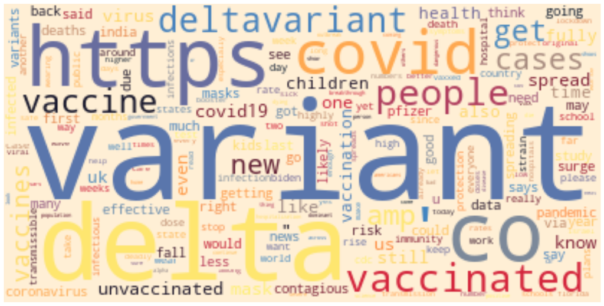

```python
hero.wordcloud(df['content'].pipe(hero.clean))
```

# DATA PREPROCESSING (CLEANING)

```python
!pip install clean-text
```

[output not shown]

```python
import html
for i in range (len(df['content'])):

  x = df['content'].replace('\n','') #cleaning newline “\n” from the tweets
df['content'][i] = html.unescape(x)
df['content'].head(10)
```

```
0     The World Health Organization (WHO) said Tuesd...
1     What We Know About the Dangerous COVID B.1.617...
2     WHO narrows in on Covid Delta variant\n\nRead ...
3     and then there's the UK, which remains the mos...
5     Guy on @BBCNewsnight the so called Delta varia...
6     @DailyMailUK Hmm... errr! It’s Delta variant, ...
7     The world is struggling to contain the delta v...
8     Delta variant - a must read.\n#trinidad https:...
9     @OleItumbi @MutahiNgunyi @MOH_Kenya @MutahiKag...
10    @WHO @WHO_Europe @WHOEMRO @pahowho @PAHOCaribb...
Name: content, dtype: object
```

# Importing NLTK libraries like stopwards and word_tokenize to perform the following Pre-Processng Tasks

- Lowercasing all your letters
- Removing hashtags, mentions, and links
- Punctuations removal (including filtering non-alphanumeric characters if necessary)
- Tokenization
- Stop words removal

```python
df['content']=df['content'].str.lower()
tweet=df['content'].values.tolist()
```

```python
import pandas as pd
import html
import re
from nltk.corpus import stopwords
from nltk.tokenize import word_tokenize
import nltk

def clean_tweet(tweet):
    if type(tweet) == np.float:
        return ""
    temp = tweet.lower()
    temp = re.sub("'", "", temp) # to avoid removing contractions in english
    temp = re.sub("@[A-Za-z0-9_]+","", temp)
    temp = re.sub("#[A-Za-z0-9_]+","", temp)
    temp = re.sub(r'http\S+', '', temp)
    temp = re.sub('[()!?]', ' ', temp)
    temp = re.sub('\[.*?\]',' ', temp)
    temp = re.sub("[^a-z0-9]"," ", temp)
    temp = temp.split()
    temp = [w for w in temp if not w in stopwords]
    temp = " ".join(word for word in temp)
    return temp
```

```python
from nltk.corpus import stopwords
stopwords = nltk.corpus.stopwords.words('english')
results = [clean_tweet(tw) for tw in tweet]
```

# IMPORTING TEXTBLOB LIBRARY TO PERFORM SENTIMENT ANALYSIS

```python
from textblob import TextBlob

import tweepy
import sys
```

# In this step we are filtering out all the '@usernames:' and then performing sentiment Analysis based on the Polarity of the tweets

- The tweets which have polarity greater then 0 are classified to be having positive sentiments
- The tweets which have polarity less then 0 are classified t be having negitive sentiments
- The rest of the tweets are considered to be Neutral tweets

```python
polarity = 0
positive = 0
negitive = 0
neutral = 0

for tweet in results :
  final_text = tweet.replace('RT','')
  if final_text.startswith('@'):
    position = final_text.index(':')
    final_text = final_text[position+2:]
  if final_text.startswith('@'):
    position = final_text.index('')
    final_text = final_text[position+2:]
  analysis = TextBlob(final_text)
  tweet_polarity = analysis.polarity
  if tweet_polarity > 0 :
    positive += 1
  elif tweet_polarity< 0 :
    negitive += 1
  else:
    neutral += 1
  polarity += tweet_polarity
print(polarity)
print(f'Amount of positive tweets:{positive}')
print(f'Amount of negitive tweets:{negitive}')
print(f'Amount of neutral tweets:{neutral}')
```

```
3396.8541876405498
Amount of positive tweets:31123
Amount of negitive tweets:16730
Amount of neutral tweets:22591
```

```python
import matplotlib.pyplot as plt
df1 = pd.DataFrame (results, columns = ['cleaned_tweets'])
df1
```

|  | cleaned_tweets |
| --- | --- |
| 0 | world health organization said tuesday one str... |
| 1 | know dangerous covid b 1 617 2 delta variant 1... |
| 2 | narrows covid delta variant read |
| 3 | theres uk remains troubling consider vaccinati... |
| 4 | guy called delta variant indian variant |
| ... | ... |
| 70439 | absolutely notice delta variant bs sounded alo... |
| 70440 | vaccinated people likely unvaccinated people s... |
| 70441 | finally virus burned much population beginning... |
| 70442 | people saying delta variant really hitting eve... |
| 70443 | inconsistency reticence amp mixed messaging db... |

70444 rows × 1 columns

# Getting the Subjectivity and the Polarity of the tweets

```python
def getSubjectivity(text):
  return TextBlob(text).sentiment.subjectivity

def getPolarity(text):
  return TextBlob(text).sentiment.polarity


df1['Subjectivity']  = df1['cleaned_tweets'].apply(getSubjectivity)
df1['Polarity']  = df1['cleaned_tweets'].apply(getPolarity)
```

```python
df1
```

[output not shown]

# Here we can visualize a Word Cloud of the cleaned tweets

```python
from wordcloud import WordCloud
```

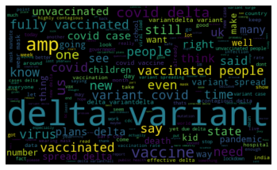

```python
allWords = ''.join([twts for twts in df1['cleaned_tweets']])
wordCloud = WordCloud(width=500,height=300,random_state=21,max_font_size=119).generate(allWords)
plt.imshow(wordCloud,interpolation = 'bilinear')
plt.axis('off')
plt.show()
```

# create a function to compute the negitive neutral and positive analysis and add it as a column in the dataframe

```python
def getAnalysis(polarity):
  if polarity < 0:
    return 'Negitive'
  elif polarity == 0:
    return 'Neutral'
  else:
    return 'Positive'



df1['Sentiments'] = df1['Polarity'].apply(getAnalysis)
df1
```

|  | cleaned_tweets | Subjectivity | Polarity | Sentiments |
| --- | --- | --- | --- | --- |
| 0 | world health organization said tuesday one str... | 0.333333 | 0.250000 | Positive |
| 1 | know dangerous covid b 1 617 2 delta variant 1... | 0.900000 | -0.600000 | Negitive |
| 2 | narrows covid delta variant read | 0.000000 | 0.000000 | Neutral |
| 3 | theres uk remains troubling consider vaccinati... | 0.200000 | 0.200000 | Positive |
| 4 | guy called delta variant indian variant | 0.000000 | 0.000000 | Neutral |
| ... | ... | ... | ... | ... |
| 70439 | absolutely notice delta variant bs sounded alo... | 0.810000 | -0.260000 | Negitive |
| 70440 | vaccinated people likely unvaccinated people s... | 1.000000 | 0.000000 | Neutral |
| 70441 | finally virus burned much population beginning... | 0.583929 | 0.021429 | Positive |
| 70442 | people saying delta variant really hitting eve... | 0.200000 | 0.200000 | Positive |
| 70443 | inconsistency reticence amp mixed messaging db... | 0.250000 | 0.000000 | Neutral |

70444 rows × 4 columns

# print all the postive tweets

```python
j =1
sortedDF =df1.sort_values(by=['Polarity'])
for i in range (0,sortedDF.shape[0]):
  if(sortedDF['Sentiments'][i]=='Positive'):
    print(str(j) + ')' + sortedDF['cleaned_tweets'][i])
    print()
    j= j+1
```

```
Streaming output truncated to the last 5000 lines.
28624)delta variant cooled u california economic outlook los angeles times courtesy share via

28625)father died something say sure care sure busy trying figure way kill ppl name thing

28626)booster dose covid 19 vaccine developed pfizer german partner biontech restored efficacy 95 6 per cent virus including delta variant data released companies large study shows hope

28627)new study pfizer shows booster 95 6 effective symptomatic covid 19 participants restoring full protection covid 19 trial conducted delta variant predominant strain read trial

28628)housing continue spur economic recovery despite delta variant

28629)booster dose covid 19 vaccine restored efficacy 95 6 per cent virus including delta variant data large study released pfizer

28630)ageguide efforts continue fight virus amp follow twitter account stay updated important data assistance finding vaccines call 630 293 5990

28631)1 vaccinated people still infected spread covid though far lower rates unvaccinated theres still risk 2 vaccine 100 perfect highest efficacy 95 100 theyre slightly less effective delta variant 82

28632)um delta variant extremely infectious stricter nz lockdown contain pretty much every lockdown mockdown delta

28633)cases among vaccinated stuck 1 700 week range new cases rapidly rising long get 50 new cases vaccinated soon id guess

28634)new cases partially fully vaccinated continue rise period ending aug 17 29 period ending oct 19 41 2 cant live virus evading vaccines

28635)4 keep mind delta variant viral load lot higher anyway may even wearing masks created sufficient evolutionary pressure delta variant become dominant quickly masks mean delta transmits thats result

28636)nz reports 102 new covid delta variant cases new zealand thursday reported 102 new cases covid 19 delta variant community increased overall infection tally 5 315 ninety four new infections

28637)age adjust data look variants delta variant vaccinations good thing

28638)pfizer vaccine effective delta variant adolescents israel study aol

28639)useful thread new ay 4 2 thanks

28640)nz similar population nsw also faced new challenges delta variant brings

28641)youve got kidding delta variant mutation know far

28642)covid vaccines 90 effective preventing delta variant deaths via

28643)fair paying recruit amp retain persistent shortage nurses amp related costs could pinch profits hospital operators amp take shine gains increased hospitalization due delta variant hospitals nationwide finding difficult fill nursing jobs
```

[output cut: 4945 more lines]

```
31116)delta variant indeed infectious thats mask wearing important masks protect others wearer dont protect wearer others much except n95 masks etc delta infectious important people wear masks

31117)new study covid positive vaccinated people likely spread delta variant unvaccinated people jack davis october 30 2021 8 34am

31118)tl dr even though delta variant potent vaccines still give good protection getting seriously sick covid disease infected meanwhile wear damn mask keep distance avoid getting infected

31119)crushing curve looks like bc govt vigilent

31120)although current vaccines remain effective preventing severe disease deaths covid 19 findings suggest vaccination alone sufficient prevent transmission delta variant household setting loooooooool

31121)delta variant transmissible associated reduced vaccine effectiveness particularly mild breakthrough infections whereas protection severe disease greatly reduced

31122)finally virus burned much population beginning year florida 23rd deaths per million right way 7th alabama done worse job delta variant florida shameful

31123)people saying delta variant really hitting even vaccinated people hospitals
```

# print all the negitive tweets

```python
j =1
sortedDF =df1.sort_values(by=['Polarity'],ascending ='False')
for i in range (0,sortedDF.shape[0]):
  if(sortedDF['Sentiments'][i]=='Negitive'):
    print(str(j) + ')' + sortedDF['cleaned_tweets'][i])
    print()
    j= j+1
```

```
Streaming output truncated to the last 5000 lines.
14231)umm stupid people getting vaccinated freedumb yet totally last year theyre also wearing masks freedumb vicious delta variant loves call dying libs

14232)covid scary delta variant

14233)delta variant afraid

14234)covid 19 singapore 10 10 2021 3 703 daily confirmed cases cases 124 157 total confirmed cases 80 population vaccinated china virus fake numbers scams 17 daily fake cases 96 374 fake cases

14235)two different countries rule different different laws thinking get point hateful fantasy americas stance change due science changing biden saying mandates delta variant

14236)psa bought delta variant proliferation association listen chief interpreter betting kids lives virus fake agency protected kids parents like delta variant said 06

14237)covid 19 global deaths hit five million delta variant spreads america crosses 7 00 000 deaths current data shows half world yet receive one shot vaccine even virus kills five

14238)weak september jobs report underscores fed misdiagnosis delta variant toll economy

14239)makes crap premise false americans died till january 20 since including january 21 death toll 2021 mostly among anti vax jerks selfishness excuse making delta variant got cull

14240)weak september jobs report busts unemployment benefits myth week war workers delta variant covid 19 continues leave mark economy another disappointing jobs report

14241)psaki grilled bidens really terrible polls blames delta variant unvaccinated americans

14242)ive read multiple statements doctors say without vaccine delta variant get lungs destroy immediately people crazy

14243)theyre unbelievable boasting disease neither ever twice ever didnt would spread fucking district delta variant arse

14244)long time since anyone claimed 95 efficacy infection delta variant brought 79 amp steadily wanes israel reports low 40 6 months efficacy serious disease amp death stronger varies age vaccination still saves lives

14245)psaki liar biden wh fauci amp cdc unmasking guidance fatal decision triggered delta variant knew unvaxxed people less 50 deceived us

14246)check mess

14247)next blaming position planets administration nearing joke status psaki grilled bidens really terrible polls blames delta variant unvaccinated americans

14248)tragic doctor eric referring covid 19 thats currently causing havoc amp heartbreak canadian provinces please specify thanku

14249)maaaaaaan day coming put criminals trial next youre going tell us delta variant far worse children previous strains right health canada dishonest

14250)well think ur idiot people covid recovered 7 times less likely catch delta variant people covid gotten vaccine tell get vaccine
```

[output cut: 4945 more lines]

```
16723)wrong mutates comes contact vaccine designed fact delta variant mutation came wuhan lab experimented 4k mutations

16724)study found covid 19 vaccines help protect vaccinated severe illness delta variant little reduce spread households

16725)actually study applies work airplanes theaters little secret jabs work controlling vaccinated likely spread delta variant within household unvaccinated study

16726)disturbing thing learned variant site sequencing almost nothing need tracking sublineages summer surge abated threat remains

16727)aside covid thisll long term strain medical healthcare system amp funding public healthcare

16728)really want fuck around find delta variant mutation dont

16729)6 months since warning 3rd wave growing exponentially uk previous variant diminishing time hospitals overwhelmed amp nobody seems even noticed

16730)absolutely notice delta variant bs sounded alot like hayfever allergies reactions jabs suited high number cases summer fucking bs staring people eyes im convinced people stupid continue years
```